# Function of the Week:

Karla Cordova Nicolas

2023-02-12

# `geom_hex()`

In this document, I will introduce the $\color{red}{\text{geom_hex()}}$ function and show what it’s for.

```r
#load tidyverse up
library(tidyverse)
#example dataset
library(palmerpenguins)
data(penguins)

#load required package 'hexbin' for 'stat_binhex()'
library(hexbin)
```

## What is it for?

geom_hex() is a function from the ggplot2 package that creates heatmaps using hexagonal shapes in two dimensions. It is used to display a continuous bivariate distribution.

### Example 1

By adding the ‘geom_hex()’ function to the ggplot() and aes() function for two desired continuous variables, you can see that there is variation in concentration throughout the graph.

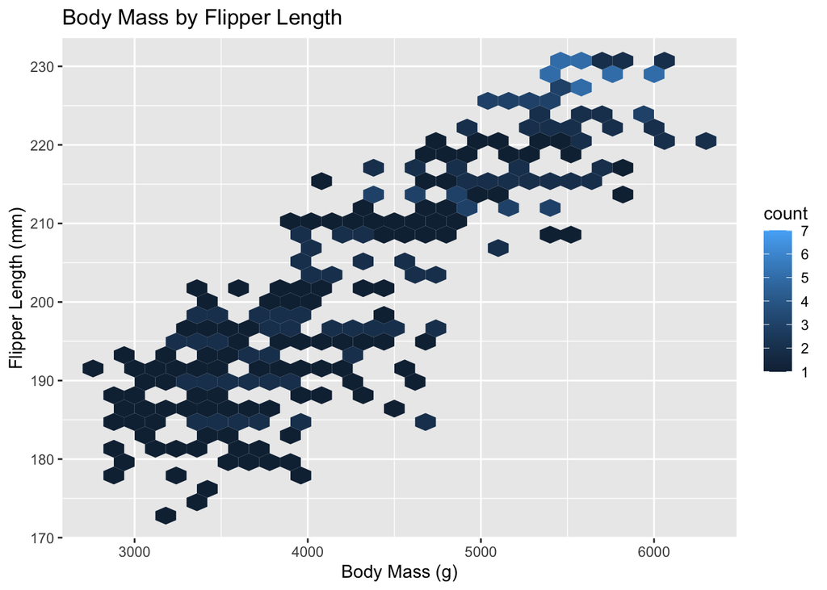

```r
ggplot(penguins) +

  aes(x = body_mass_g,
      y = flipper_length_mm) +

  labs(title = "Body Mass by Flipper Length",
       x = "Body Mass (g)",
       y = "Flipper Length (mm)") +

  geom_hex()
```

### Example 2

Other options can be added to change the way the information is displayed on your graph.

The number of bins determines how many hexagon/bins are displayed in both vertical and horizontal directions. The default number of bins is 30, but you can change the number of bins with the option ‘bins =’:

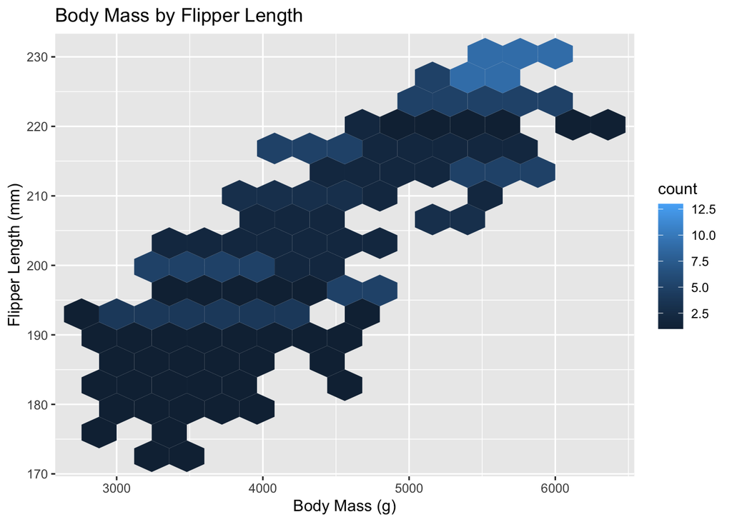

```r
ggplot(penguins) +

  aes(x = body_mass_g,
      y = flipper_length_mm) +

    labs(title = "Body Mass by Flipper Length",
       x = "Body Mass (g)",
       y = "Flipper Length (mm)") +

  geom_hex(bins = 15)
```

### Example 3

As with other functions in the ggplot2 package, multiple options like ‘binwidth()’, ‘scale_fill_gradient()’, and ‘fill =’ within aes() can be used.

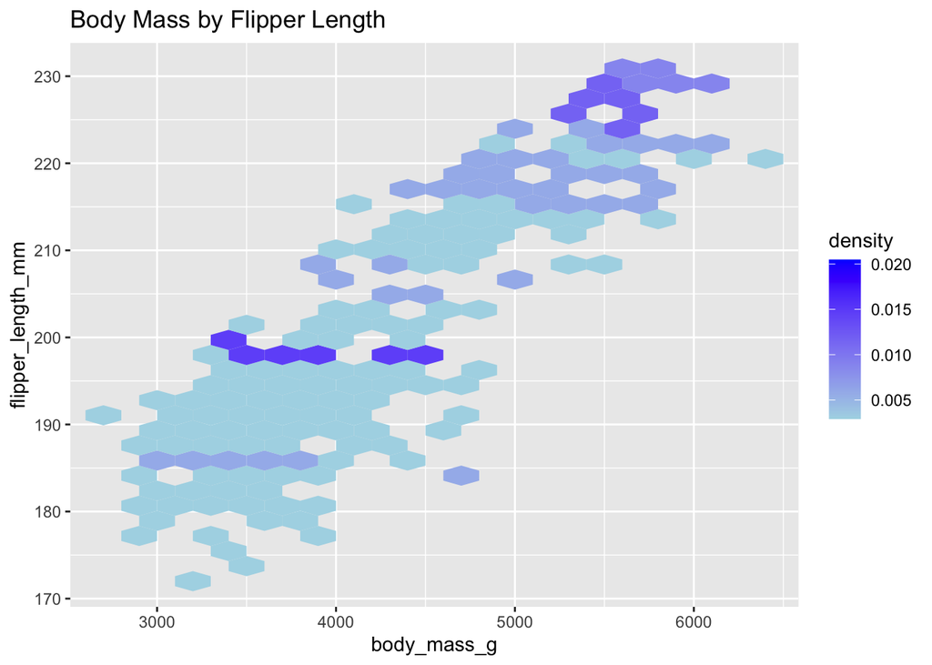

```r
ggplot(penguins) +

      labs(title = "Body Mass by Flipper Length",
       x = "Body Mass (g)",
       y = "Flipper Length (mm)") +

  aes(x = body_mass_g,
      y = flipper_length_mm,
      fill = ..density..) +
              # count is the default option, but you can change it to density with 'fill ='
  geom_hex(binwidth = c(200, 2)) +
              # 'binwidth' is used to adjust the hexagon size horizontally and vertically
  scale_fill_gradient (low = "light blue", high = "blue")   # with 'scale_fill_gradient' you can change the color
```

## Is it helpful?

geom_hex() allows you to better visualize areas where your data is concentrated and thus makes it easier to read.